# R Notebook

```r
library(readr)
library(tidyr)
library(dplyr)
library(stringr)
library(tibble)
library(lubridate)
library(ggplot2)
```

```r
ks2018 <- read_csv("ks-projects-201801.csv") %>% as.tibble()

glimpse(ks2018)
summary(ks2018)
```

```r
ks18_1 <- ks2018
#categorise columns correctly and view levels
factor_names <- c("category", "main_category", "currency", "state", "country")
ks18_1[factor_names] <- lapply(ks18_1[factor_names], factor)
sapply(ks18_1[factor_names], levels)

ks18_1$ID <- as.character(ks18_1$ID)
```

```r
#usd_pledged is the only category with NAs. It only has 1% NAs
summary(ks18_1)
mean(is.na(ks18_1$`usd pledged`))
sapply(ks18_1, function(x) {sum(is.na(x))})
sapply(ks18_1, function(x) {mean(is.na(x))})
```

# floor round the ymd_hms values to ymd. ymd() converts from from “POSIXct” “POSIXt” to “Date”

# and also removed the UTC part

```r
ks18_1$launched <- ks18_1$launched %>% floor_date(unit = "day") %>% ymd()
ks18_1 <- ks18_1 %>% mutate(duration = deadline - launched)

glimpse(ks18_1)
```

```r
#which are the highest funded projects
ks18_1 %>% arrange(desc(usd_pledged_real)) %>% head(15)
```

```r
#which are the most backed projects
ks18_1 %>% arrange(desc(backers)) %>% head(15)
```

```r
#which are the most popular types of main-category
#rearrange factors in main_category according to number of projects in that category

pop_main_cats <- ks18_1 %>% group_by(main_category) %>%
  summarise(number_of_projects = n()) %>%
  arrange(desc(number_of_projects))

#if you just factor a column without specifying the levels it will create levels in alphabetical order
#and this will be the order of the bars in the charts too

pop_main_cats$main_category <- factor(pop_main_cats$main_category, levels = pop_main_cats$main_category)
```

```r
jtheme1 <-   theme(plot.title = element_text(size = 14, face = "bold", hjust = 0.5), axis.title = element_text(face = "bold"), axis.text.x = element_text(angle = 90, vjust = 0.5)) +
  theme(legend.position = "none")
```

```r
pop_main_cats %>% ggplot(aes(main_category, number_of_projects)) +
geom_col(aes(fill = main_category)) +
  ggtitle("Number of Projects per Category") +
  xlab("Main Category") +
  ylab("Number of Projects") +
  theme_classic() +
  jtheme1
```

```r
pop_sub_cats <- ks18_1 %>% group_by(category, main_category) %>%
  summarise(number_of_projects = n()) %>%
  arrange(desc(number_of_projects)) %>%
  head(20)

pop_sub_cats$category <- factor(pop_sub_cats$category, levels = pop_sub_cats$category)
```

Taking the 20 most popular subcategories

```r
pop_sub_cats %>% ggplot(aes(category, number_of_projects)) +
  geom_col(aes(fill = category)) +
  ggtitle("Number of Projects per Sub-Category") +
  xlab("Sub Category") +
  ylab("Number of Projects") +
  theme_classic() +
  jtheme1
```

Which categories get the most money?

```r
pledged_per_maincat <- ks18_1 %>% group_by(main_category) %>%
  summarise(amnt_pledged = sum(usd_pledged_real)) %>%
  arrange(desc(amnt_pledged))

pledged_per_maincat$main_category <- factor(pledged_per_maincat$main_category, levels = pledged_per_maincat$main_category)

pledged_per_maincat %>% ggplot(aes(main_category, (amnt_pledged/10^6))) +
  geom_col(aes(fill = main_category)) +
  ggtitle("Amount Pledged per Catergory") +
  xlab("Category") + ylab("Amount Pledged (USD) millions") +
  theme_classic() +
  jtheme1
```

Which subgategories of games get the most money?

```r
pledged_games_per_subcat <- ks18_1 %>% filter(main_category == "Games") %>%
  group_by(category) %>%
  summarise(amnt_pledged = sum(usd_pledged_real)) %>%
  arrange(desc(amnt_pledged))

pledged_games_per_subcat$category <- factor(pledged_games_per_subcat$category, levels = pledged_games_per_subcat$category)

pledged_games_per_subcat %>% ggplot(aes(category, (amnt_pledged/10^6))) +
  geom_col(aes(fill = category)) +
  ggtitle("Amount Pledged per Games Sub-Catergory") +
  xlab("Sub-Category") + ylab("Amount Pledged (USD) millions") +
  theme_classic() +
  jtheme1
```

Which catgories get the most backers?

```r
backers_per_maincat <- ks18_1 %>% group_by(main_category) %>%
  summarise(no_backers = sum(backers)) %>%
  arrange(desc(no_backers))

backers_per_maincat$main_category <- factor(backers_per_maincat$main_category, levels = backers_per_maincat$main_category)

backers_per_maincat %>% ggplot(aes(main_category, no_backers/1000000)) +
  geom_col(aes(fill = main_category)) +
  ggtitle("Number of Backers per Category (Millions)") +
  xlab("Category") + ylab("Number of Backers") +
  theme_classic() +
  jtheme1
```

Which subcategories of games get the most backers?

```r
backers_games_per_subcat <- ks18_1 %>%
  filter(main_category == "Games") %>%
  group_by(category) %>%
  summarise(no_backers = sum(backers)) %>%
  arrange(desc(no_backers))

backers_games_per_subcat$category <- factor(backers_games_per_subcat$category, levels = backers_games_per_subcat$category)

backers_games_per_subcat %>% ggplot(aes(category, no_backers/1000000)) +
  geom_col(aes(fill = category)) +
  ggtitle("Number of Backers per Games Sub-Category") +
  xlab("Sub-Category") + ylab("Number of Backers (Millions)") +
  theme_classic() +
  jtheme1
```

Which categories have the most “generous” backers?

```r
pledge_per_backer <- ks18_1 %>%
  group_by(main_category) %>%
  summarise(pledged = sum(usd_pledged_real), backers = sum(backers)) %>%
  mutate(ppb = pledged/backers) %>%
  arrange(desc(ppb))

pledge_per_backer$main_category <- factor(pledge_per_backer$main_category, levels = pledge_per_backer$main_category)

pledge_per_backer %>% ggplot(aes(main_category, ppb)) +
  geom_col(aes(fill=main_category)) +
  ggtitle("Most 'Generous' Backers") +
  xlab("Category") + ylab("Average Pledge per Backer (USD)") +
  theme_classic() +
  jtheme1
```

Which subcategories of technology have the most “generous” backers?

```r
pledge_per_backer <- ks18_1 %>%
  filter(main_category == "Technology") %>%
  group_by(category) %>%
  summarise(pledged = sum(usd_pledged_real), backers = sum(backers)) %>%
  mutate(ppb = pledged/backers) %>%
  arrange(desc(ppb))

pledge_per_backer$category <- factor(pledge_per_backer$category, levels = pledge_per_backer$category)

pledge_per_backer %>% ggplot(aes(category, ppb)) +
  geom_col(aes(fill=category)) + ylim(0,425) +
  ggtitle("Most 'Generous' Technology Backers") +
  xlab("Sub-Category") + ylab("Average Pledge per Backer (USD)") +
  theme_classic() +
  jtheme1
```

Let’s compare this to the Games backers

```r
games_pledge_per_backer <- ks18_1 %>%
  filter(main_category == "Games") %>%
  group_by(category) %>%
  summarise(pledged = sum(usd_pledged_real), backers = sum(backers)) %>%
  mutate(ppb = pledged/backers) %>%
  arrange(desc(ppb))

games_pledge_per_backer$category <- factor(games_pledge_per_backer$category, levels = games_pledge_per_backer$category)

games_pledge_per_backer %>% ggplot(aes(category, ppb)) +
  geom_col(aes(fill=category)) + ylim(0,425) +
  ggtitle("Most 'Generous' Games Backers") +
  xlab("Sub-Category") + ylab("Average Pledge per Backer (USD)") +
  theme_classic() +
  jtheme1
```

Sometimes the mean per main categories does not give a good representation. Which subcategories have the most generous backers.

```r
pledge_per_backer_per_subcat <- ks18_1 %>%
  group_by(category, main_category) %>%
  summarise(pledged = sum(usd_pledged_real), backers = sum(backers)) %>%
  mutate(ppb = pledged/backers) %>%
  arrange(desc(ppb)) %>%
  head(20)

pledge_per_backer_per_subcat$category <- factor(pledge_per_backer_per_subcat$category, levels = pledge_per_backer_per_subcat$category)

pledge_per_backer_per_subcat %>% ggplot(aes(category, ppb)) +
  geom_col(aes(fill=main_category)) + ylim(0,425) +
  ggtitle("Most 'Generous' Backers") +
  xlab("Sub-Category") + ylab("Average Pledge per Backer (USD)") +
  theme_classic() +
  jtheme1  +
  theme(legend.position = "right") +
  guides(fill=guide_legend(title="Main Category"))
```

which categories have the most successful projects?

```r
cat_state <- ks18_1 %>% filter(state %in% c("failed", "successful")) %>% group_by(main_category, state) %>%
  summarise(count = n())

cat_state %>% ggplot(aes(main_category, count, fill = state)) +
  geom_col(position = "fill") +
  ggtitle("Success Rate per Category") +
  xlab("Category") + ylab("") +
  theme_classic() +
  jtheme1 +
  theme(legend.position = "right") + guides(fill=guide_legend(title="")) +
  coord_flip()
```

What is the goal range for successful projects?

```r
ks18_1 %>% filter(state == "successful", usd_goal_real <= 100000) %>%
  select(usd_goal_real) %>%
  arrange(desc(usd_goal_real)) %>%

ggplot(aes(usd_goal_real)) +
  geom_density() +
  ggtitle("Goals of successful projects") +
  theme(plot.title = element_text(size = 14, face = "bold", hjust = 0.5))
```

What is the range pledged for successful projects?

```r
ks18_1 %>% filter(state == "successful") %>%
  arrange(desc(usd_pledged_real)) %>%
  select(usd_pledged_real)

ks18_1 %>% filter(state == "successful") %>%
  ggplot(aes(usd_pledged_real)) +
  geom_density() + xlim(0,50000) +
  ggtitle("goals of successful projects") +
  theme(plot.title = element_text(size = 14, face = "bold", hjust = 0.5))
```

What is the range of backers for successful projects?

```r
ks18_1 %>% filter(state == "successful") %>%
  arrange(desc(backers)) %>%
  select(backers)

ks18_1 %>% filter(state == "successful") %>%
  ggplot(aes(backers)) +
  geom_density() + xlim(0,1000) +
  ggtitle("backers of successful projects") +
  theme(plot.title = element_text(size = 14, face = "bold", hjust = 0.5))
```

What is the duration of successful projects?

```r
ks18_1 %>% select(duration) %>%
          arrange(desc(duration))
```

| duration |
| --- |
| 16739 days |
| 14867 days |
| 14835 days |
| 14761 days |
| 14750 days |
| 14733 days |
| 14709 days |
| 92 days |
| 92 days |
| 92 days |

[output cut: 990 more lines]

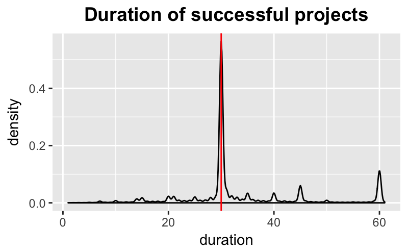

```r
ks18_1 %>% filter(duration <= 61) %>%
 ggplot(aes(duration)) +
  geom_density() +
  geom_vline(xintercept = 30, col = "red") +
  ggtitle("Duration of successful projects") +
  theme(plot.title = element_text(size = 14, face = "bold", hjust = 0.5))
```

both successful and unsuccessful projects have similar durations

```r
ks18_1 %>% filter(duration <= 61, state %in% c("successful", "failed")) %>%
 ggplot(aes(duration, col = state)) +
  geom_density(alpha = 0.4) +
  ggtitle("The range of failed and successful projects follows a similar pattern") +
  theme(plot.title = element_text(size = 8, face = "bold", hjust = 0.5))
```

```r
top1000 <- ks18_1 %>% filter(state == "successful") %>%
  arrange(desc(usd_pledged_real)) %>%
  head(1000)

top1000 %>% ggplot(aes(backers)) +
  geom_dotplot()

top100 %>% ggplot(aes(usd_pledged_real/1000000)) +
  geom_dotplot(bins = 100) + xlab("Amount pledged (USD Millions)")

top100 %>% group_by(main_category) %>%
  summarise(total = sum(usd_pledged_real)) %>%
  ggplot(aes(main_category, total/1000000)) +
  geom_col() + ylab("Amount pledged (USD Millions)")
```

```r
top20 <- ks18_1 %>% filter(state == "successful") %>%
  arrange(desc(usd_pledged_real)) %>%
  head(20)

top20 %>% ggplot(aes(backers)) +
  geom_dotplot()

top20 %>% ggplot(aes(usd_pledged_real/1000000)) +
  geom_dotplot() + xlab("Amount pledged (USD Millions)")

top20 %>% group_by(main_category) %>%
  summarise(total = sum(usd_pledged_real)) %>%
  ggplot(aes(main_category, total/1000000)) +
  geom_col() + ylab("Amount pledged (USD Millions)")
```

which times of year have highest number of backers, and pledge amnts

```r
ks18_1 %>% filter(duration <= 61, state %in% c("successful", "failed"), usd_goal_real < 500000) %>%
  ggplot(aes(duration, usd_goal_real, col = state)) +
  geom_jitter(width=0.25, size = 0.25, alpha = 0.3)
```

**which times of year have highest number of backers, and pledge amnts**

The number of successful projects has gone up over time

```r
ks18_1 %>%
  mutate(endmonth = floor_date(deadline, unit = "month")) %>%
  filter(duration <= 61, state %in% c("successful", "failed"), usd_goal_real < 500000) %>%
  group_by(endmonth, state) %>%
  summarise(total = n()) %>%
  ggplot(aes(endmonth, total, col = state)) +
  geom_point(size = 0.25, alpha = .75) +
  ggtitle("Number of Projects per Month") +
  theme(plot.title = element_text(size = 14, face = "bold", hjust = 0.5))
```

The average amount of money pledged (per successful project) has gone up over time. There seems to be some time pattern, at least with amount pledged for failed projects.

```r
ks18_1 %>%
  mutate(endmonth = floor_date(deadline, unit = "month")) %>%
  filter(duration <= 61, state %in% c("successful", "failed"), usd_goal_real < 500000) %>%
  group_by(endmonth, state) %>%
  summarise(totalnorm = mean(usd_pledged_real)) %>%
  ggplot(aes(endmonth, totalnorm, col = state)) +
  geom_point(size = 0.25) +
  geom_line(alpha = 0.4) +
  ggtitle("Average Amount Pledged per Month") +
  xlab("End Month") + ylab("Average Amount Pledged (USD)") +
  theme(plot.title = element_text(size = 14, face = "bold", hjust = 0.5))
```

```r
ks18_1 %>%
  mutate(endmonth = floor_date(deadline, unit = "month")) %>%
  filter(duration <= 61, state %in% c("failed"), usd_goal_real < 500000) %>%
  group_by(endmonth, state) %>%
  summarise(totalnorm = mean(usd_pledged_real)) %>%
  ggplot(aes(endmonth, totalnorm)) +
  geom_point( size = 0.25) +
  geom_line(alpha = 0.3, col = "blue") +
  ggtitle("Amount pledged - unsuccessful") +
  xlab("End Month") + ylab("Average amount pledged per month") +
  jtheme1
```

The amount of pledged to successful projects has increased

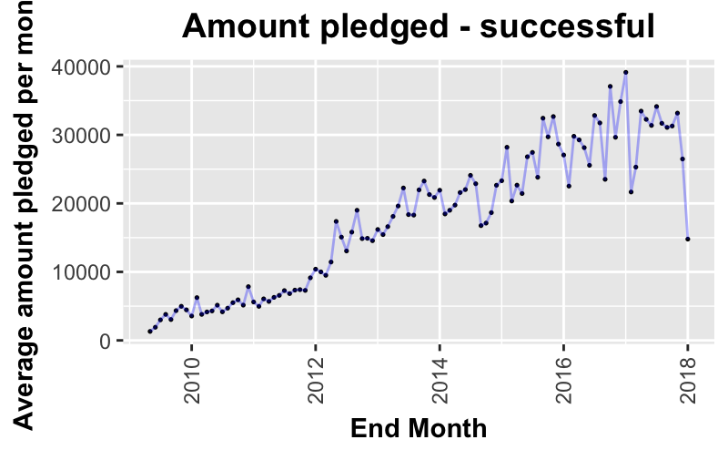

```r
ks18_1 %>%
  mutate(endmonth = floor_date(deadline, unit = "month")) %>%
  filter(duration <= 61, state %in% c("successful"), usd_goal_real < 500000) %>%
  group_by(endmonth, state) %>%
  summarise(totalnorm = mean(usd_pledged_real)) %>%
  ggplot(aes(endmonth, totalnorm)) +
  geom_point( size = 0.25) +
  geom_line(alpha = 0.3, col = "blue") +
  ggtitle("Amount pledged - successful") +
  xlab("End Month") + ylab("Average amount pledged per month") +
  jtheme1
```

Which end days have more pledges? **decide on correct cut offs**

```r
ks18_1 %>%
  mutate(endday = wday(deadline, label = TRUE, abbr = TRUE, week_start = getOption("lubridate.week.start", 1))) %>%
  filter(duration <= 61, state %in% c("successful"), usd_goal_real < 500000) %>%
  group_by(endday, state) %>%
  summarise(totalnorm = mean(usd_pledged_real)) %>%
  ggplot(aes(endday, totalnorm)) +
  geom_col(aes(fill = endday)) +
  ggtitle("Average Amount Pledged per End Day - Successful ") +
  xlab("End Day") + ylab("Amount Pledged (USD)") +
  theme_classic() +
  jtheme1

ks18_1 %>%
  mutate(endday = wday(deadline, label = TRUE, abbr = TRUE, week_start = getOption("lubridate.week.start", 1))) %>%
  filter(duration <= 61, state %in% c("failed"), usd_goal_real < 500000) %>%
  group_by(endday, state) %>%
  summarise(totalnorm = mean(usd_pledged_real)) %>%
  ggplot(aes(endday, totalnorm)) +
  geom_col(aes(fill = endday)) +
  ggtitle("Average Amount Pledged per End Day - Failed") +
  xlab("End Day") + ylab("Amount Pledged (USD)") +
  theme_classic() +
  jtheme1
```

What is the chance of success per week day?

```r
ks18_1 %>%
  mutate(endday = wday(deadline, label = TRUE, abbr = TRUE, week_start = getOption("lubridate.week.start", 1))) %>%
  filter(duration <= 61, state %in% c("successful", "failed"), usd_goal_real < 500000) %>%
  group_by(endday, state) %>%
  summarise(count = n()) %>%
  mutate(pct = count/sum(count)) %>%
ggplot(aes(endday, pct, fill = state)) +
  geom_col(position = "fill") +
  geom_text(aes(label=paste0(round(pct*100,1),"%")), position=position_stack(vjust=0.5),
            colour="white", size=5) +
  ggtitle("Number of Projects") +
  xlab("End Day") + ylab("") +
  theme_classic() +
  jtheme1 +
  theme(legend.position = "right")
```

Is the difference between success rate per day significant?

```r
ks18_1 %>%
  filter(state %in% c("successful", "failed"))%>%
  mutate(success = state == "successful") %>%
  group_by(deadline) %>%
  summarise(success_rate = mean(success)) %>%
  mutate(endday = wday(deadline, label = TRUE, abbr = TRUE, week_start = getOption("lubridate.week.start", 1))) %>%
  ggplot(aes(endday, success_rate * 100, col = endday)) +
  geom_jitter(size = 0.75, alpha = 0.4, width = 0.1) +
  ggtitle("Success Rate per Week Day") +
  xlab("Day of Week") + ylab("Success Rate (%)") +
  theme(plot.title = element_text(size = 14, face = "bold", hjust = 0.5), axis.title = element_text(face = "bold"), axis.text.x = element_text(vjust = 0.5)) +
  theme(legend.position = "none")
```

Is there a big difference between success rate and month?

```r
ks18_1 %>%
  filter(state %in% c("successful", "failed"))%>%
  mutate(success = state == "successful") %>%
  group_by(deadline) %>%
  summarise(success_rate = mean(success)) %>%
  mutate(mnth = month(deadline, label = TRUE, abbr = TRUE)) %>%
  ggplot(aes(mnth, success_rate * 100, col = mnth)) +
  geom_jitter(size = 0.75, alpha = 0.4, width = 0.1) +
  ggtitle("Success Rate per Month") +
  xlab("Month of Year") + ylab("Success Rate (%)") +
  theme(plot.title = element_text(size = 14, face = "bold", hjust = 0.5), axis.title = element_text(face = "bold"), axis.text.x = element_text(vjust = 0.5)) +
  theme(legend.position = "none")
```

Is there a big difference between amount pledged and month?

```r
ks18_1 %>%
  filter(state %in% c("successful", "failed"), usd_pledged_real < 500000)%>%
  group_by(deadline) %>%
  summarise(pledged = mean(usd_pledged_real)) %>%
  mutate(mnth = month(deadline, label = TRUE, abbr = TRUE)) %>%
  ggplot(aes(mnth, pledged, col = mnth)) +
  geom_jitter(size = 0.75, alpha = 0.4, width = 0.1) +
  ggtitle("Amount Pledged per Month") +
  xlab("Month of Year") + ylab("Amount Pledged (USD)") +
  theme(plot.title = element_text(size = 14, face = "bold", hjust = 0.5), axis.title = element_text(face = "bold"), axis.text.x = element_text(vjust = 0.5)) +
  theme(legend.position = "none")
```

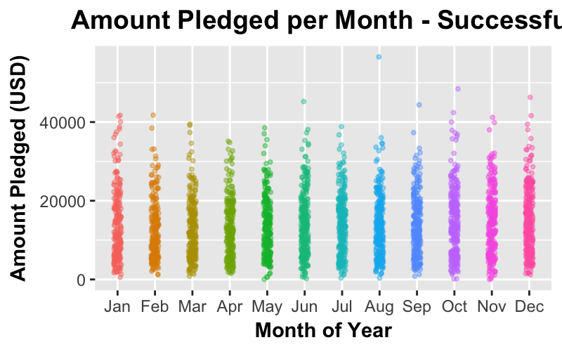

```r
ks18_1 %>%
  filter(state %in% c("successful"), usd_pledged_real < 500000) %>%
  group_by(deadline) %>%
  summarise(pledged = mean(usd_pledged_real)) %>%
  mutate(mnth = month(deadline, label = TRUE, abbr = TRUE)) %>%
  ggplot(aes(mnth, pledged, col = mnth)) +
  geom_jitter(size = 0.75, alpha = 0.4, width = 0.1) +
  ggtitle("Amount Pledged per Month - Successful") +
  xlab("Month of Year") + ylab("Amount Pledged (USD)") +
  theme(plot.title = element_text(size = 14, face = "bold", hjust = 0.5), axis.title = element_text(face = "bold"), axis.text.x = element_text(vjust = 0.5)) +
  theme(legend.position = "none")
```

```r
avg_pledge <- ks18_1 %>%
  mutate(endday = wday(deadline, label = TRUE, abbr = TRUE, week_start = getOption("lubridate.week.start", 1))) %>%
  filter(duration <= 61, state %in% c("successful"), usd_pledged_real < 500000) %>%
  group_by(endday) %>%
  summarise(avg_pledged = mean(usd_pledged_real))

ks18_1 %>%
  mutate(endday = wday(deadline, label = TRUE, abbr = TRUE, week_start = getOption("lubridate.week.start", 1))) %>%
  filter(state %in% c("successful"), usd_pledged_real < 500000)%>%
  group_by(deadline, endday) %>%
  summarise(pledged = mean(usd_pledged_real)) %>%
  ggplot(aes(endday, pledged, col = endday)) +
  geom_point(size = 0.75, alpha = 0.4, position = "jitter", width = 0.1) +
  geom_point(data=avg_pledge, aes(endday, avg_pledged), shape=95, size=15) +
  ggtitle("Amount Pledged per Week Day - Successful") +
  xlab("Day of Week") + ylab("Amount Pledged (USD)") +
  theme(plot.title = element_text(size = 14, face = "bold", hjust = 0.5), axis.title = element_text(face = "bold"), axis.text.x = element_text(vjust = 0.5)) +
  theme(legend.position = "none")
```

how does duration correlate to amount pledged how does duration correlate to likelihood to reach goal which week day is it best to start and end on?